# Mobility - Picking up things with fingers

# 1 Description of DataSchema variable

The description of harmonised variable is the following:

- Short name: `mob_coin`
- Variable label: `Difficulty for picking up things with fingers`
- Variable description: `Difficulty for picking up things with fingers, e.g. picking up a coin.`
- Domain: `Health status and functional limitations`
- Value type: `categorical`
- Category coding:

| **Code** | **Category Label** |
| --- | --- |
| 0 | Yes |
| 1 | No |

- Category missings:

| **Code** | **Category Label** |
| --- | --- |
| 991 | CAPI/interviewer error |
| 992 | Impute |
| 993 | Disable to measure |
| 994 | Not attempt/not done |
| 995 | Does not answer |
| 996 | Not applicable |
| 997 | Refuse |
| 998 | Do not know |
| 999 | Missing |

# 2 Data process

## 2.1 England

### 2.1.1 Wave 1

#### 2.1.1.1 Study-specific variable description

| **Name** | `hemobpi` |
| --- | --- |
| **Label** | `Difficulty picking up 5p coin from table` |
| **Table name** | `wave_1_ifs_derived_variables` |
| **Categories** | `0 = No; 1 = Yes` |
| **Missings** | `-9 = Refusal; -8 = Don't Know; -1 = Not applicable` |
| **Description** |  |

hemobpi

| Sample size | Missing values |
| --- | --- |
| 12099 | 191 |

Category

|  | 0 | 1 |
| --- | --- | --- |
| Frequency | 11307.00 | 601.00 |
| Percentage | 93.45 | 4.97 |

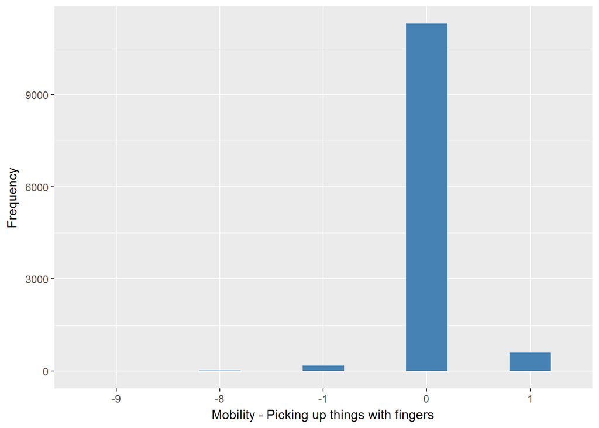

#### 2.1.1.2 Harmonisation algorithm

To compute the harmonize variable from the study-specific variable it has to be recoded as follows:

- `1 into 0`
- `0 into 1`
- `-9 Refusal into 997`
- `-8 Don't know into 998`
- `-1 Not applicable into 996`

**R script:**

```r
ELSA_ds_w1 <- tibble(id = ELSA_w1_mob_coin$id)
ELSA_ds_w1$mob_coin <- car::recode(ELSA_w1_mob_coin$hemobpi, "0 = '1';1 = '0';-9 = '997';-8 = '998';-1 = '996' ")
ELSA_ds_w1$mob_coin <- labelled(ELSA_ds_w1$mob_coin, labels = c(Yes = 0, No = 1,
    Missing = 999, Do_not_know = 998, Refuse = 997, Not_applicable = 996, Does_not_answer = 995,
    Not_attempt_not_done = 994, Disable_to_measure = 993, Impute = 992, CAPI_interviewer_error = 991))
```

#### 2.1.1.3 Statistical description of the new harmonised variable

mob_coin

| Sample size | Missing values |
| --- | --- |
| 12099 | 191 |

Category

|  | 0 | 1 |
| --- | --- | --- |
| Frequency | 601.00 | 11307.00 |
| Percentage | 4.97 | 93.45 |

Type of missing

|  | 991 | 992 | 993 | 994 | 995 | 996 | 997 | 998 | 999 | NA |
| --- | --- | --- | --- | --- | --- | --- | --- | --- | --- | --- |
| Frequency | 0 | 0 | 0 | 0 | 0 | 175.00 | 4.00 | 12.0 | 0 | 0 |
| Percentage | 0 | 0 | 0 | 0 | 0 | 1.45 | 0.03 | 0.1 | 0 | 0 |

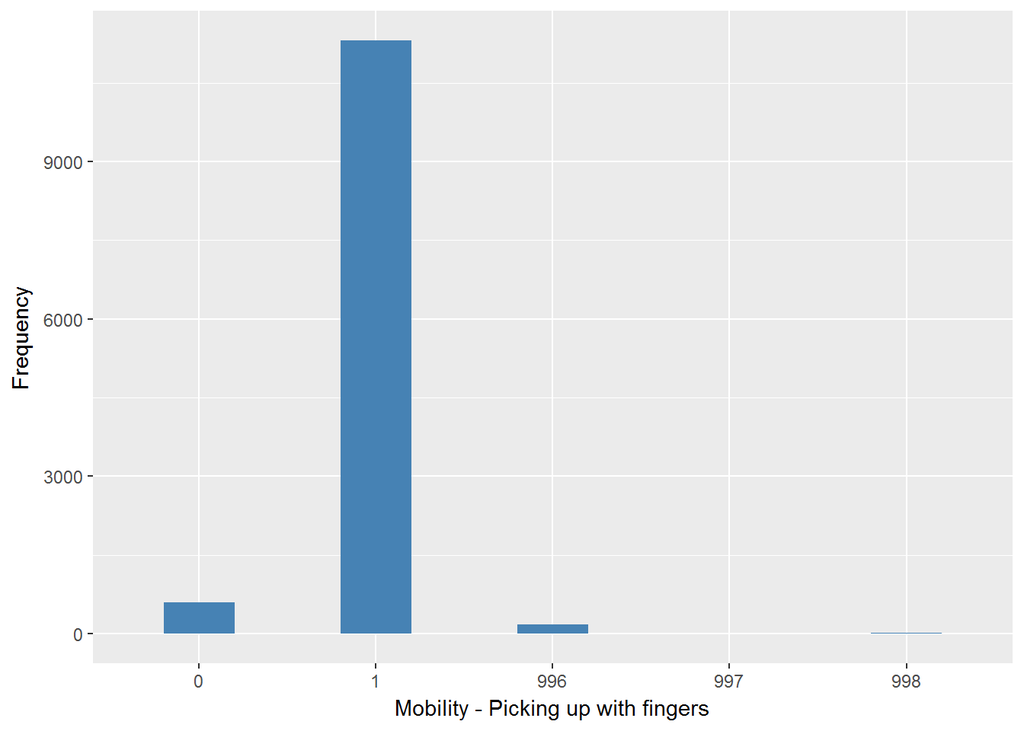

#### 2.1.1.4 Validation

|  | 1->0 | 0->1 | -1->996 | -9->997 | -8->998 |
| --- | --- | --- | --- | --- | --- |
| BeforeH | 601 | 11307 | 175 | 4 | 12 |
| AfterH | 601 | 11307 | 175 | 4 | 12 |

### 2.1.2 Wave 2

#### 2.1.2.1 Study-specific variable description

| **Name** | `hemobpi` |
| --- | --- |
| **Label** | `Difficulty picking up 5p coin from table` |
| **Table name** | `wave_2_ifs_derived_variables` |
| **Categories** | `0 = No; 1 = Yes` |
| **Missings** | `-9 = Refusal; -8 = Don't Know` |
| **Description** |  |

hemobpi

| Sample size | Missing values |
| --- | --- |
| 9432 | 3 |

Category

|  | 0 | 1 |
| --- | --- | --- |
| Frequency | 8919.00 | 510.00 |
| Percentage | 94.56 | 5.41 |

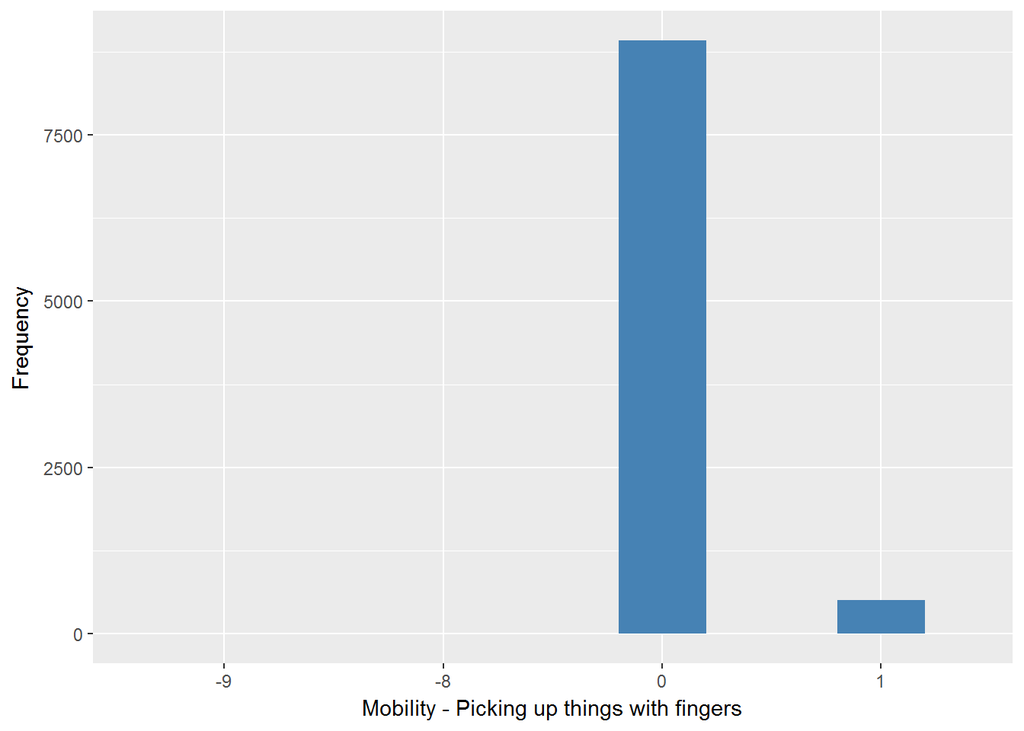

#### 2.1.2.2 Harmonisation algorithm

To compute the harmonize variable from the study-specific variable it has to be recoded as follows:

- `1 into 0`
- `0 into 1`
- `-9 Refusal into 997`
- `-8 Don't know into 998`

**R script:**

```r
ELSA_ds_w2 <- tibble(id = ELSA_w2_mob_coin$id)
ELSA_ds_w2$mob_coin <- car::recode(ELSA_w2_mob_coin$hemobpi, "0 = '1';1 = '0';-9 = '997';-8 = '998' ")
ELSA_ds_w2$mob_coin <- labelled(ELSA_ds_w2$mob_coin, labels = c(Yes = 0, No = 1,
    Missing = 999, Do_not_know = 998, Refuse = 997, Not_applicable = 996, Does_not_answer = 995,
    Not_attempt_not_done = 994, Disable_to_measure = 993, Impute = 992, CAPI_interviewer_error = 991))
```

#### 2.1.2.3 Statistical description of the new harmonised variable

mob_coin

| Sample size | Missing values |
| --- | --- |
| 9432 | 3 |

Category

|  | 0 | 1 |
| --- | --- | --- |
| Frequency | 510.00 | 8919.00 |
| Percentage | 5.41 | 94.56 |

Type of missing

|  | 991 | 992 | 993 | 994 | 995 | 996 | 997 | 998 | 999 | NA |
| --- | --- | --- | --- | --- | --- | --- | --- | --- | --- | --- |
| Frequency | 0 | 0 | 0 | 0 | 0 | 0 | 1.00 | 2.00 | 0 | 0 |
| Percentage | 0 | 0 | 0 | 0 | 0 | 0 | 0.01 | 0.02 | 0 | 0 |

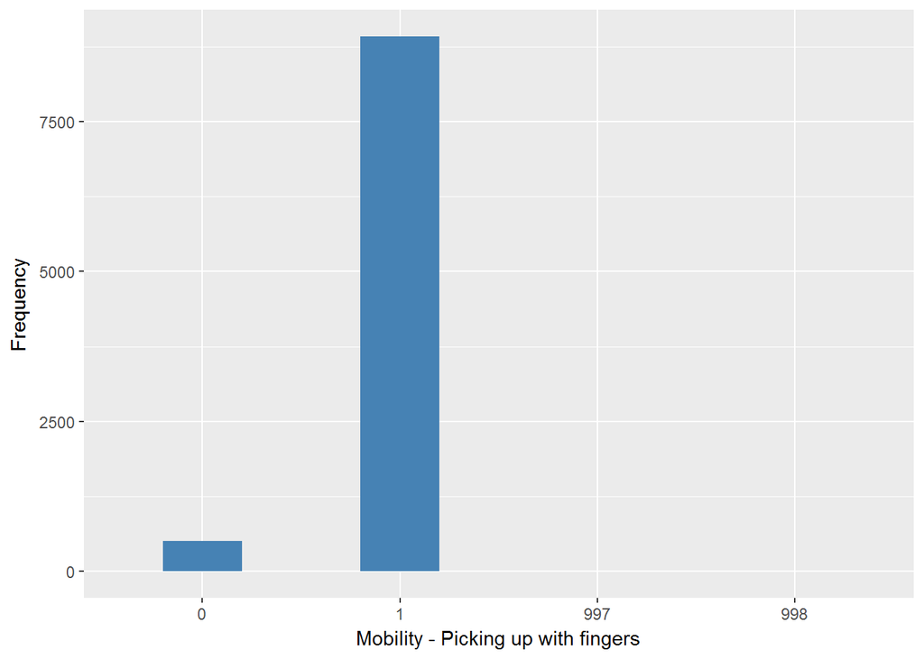

#### 2.1.2.4 Validation

|  | 1->0 | 0->1 | -9->997 | -8->998 |
| --- | --- | --- | --- | --- |
| BeforeH | 510 | 8919 | 1 | 2 |
| AfterH | 510 | 8919 | 1 | 2 |

### 2.1.3 Wave 3

#### 2.1.3.1 Study-specific variable description

| **Name** | `hemobpi` |
| --- | --- |
| **Label** | `Difficulty picking up 5p coin from table` |
| **Table name** | `wave_3_elsa_data_v4` |
| **Categories** | `0 = No; 1 = Yes` |
| **Missings** | `-1 = Not applicable` |
| **Description** |  |

hemobpi

| Sample size | Missing values |
| --- | --- |
| 9771 | 4 |

Category

|  | 0 | 1 |
| --- | --- | --- |
| Frequency | 9239.00 | 528.0 |
| Percentage | 94.56 | 5.4 |

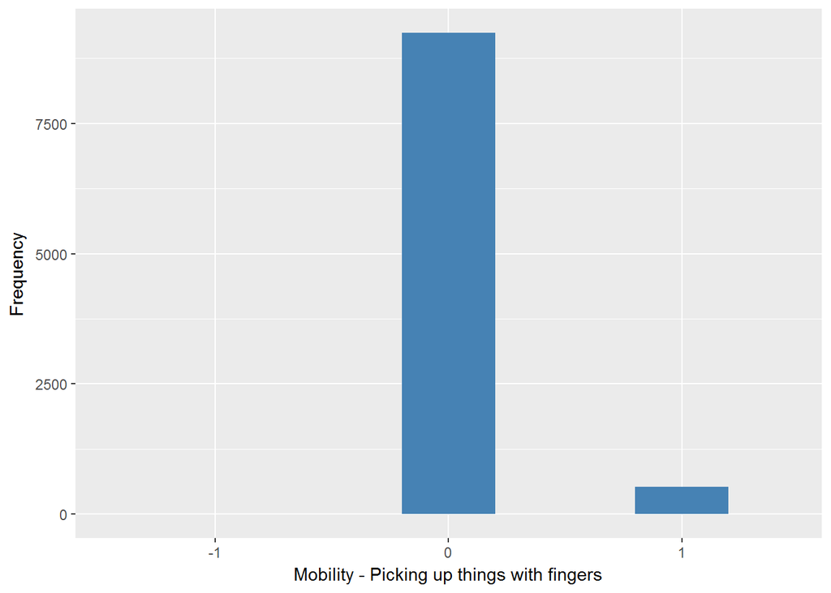

#### 2.1.3.2 Harmonisation algorithm

To compute the harmonize variable from the study-specific variable it has to be recoded as follows:

- `1 into 0`
- `0 into 1`
- `-1 Not applicable into 996`

**R script:**

```r
ELSA_ds_w3 <- tibble(id = ELSA_w3_mob_coin$id)
ELSA_ds_w3$mob_coin <- car::recode(ELSA_w3_mob_coin$hemobpi, "0 = '1';1 = '0';-9 = '997';-8 = '998';-1 = '996' ")
ELSA_ds_w3$mob_coin <- labelled(ELSA_ds_w3$mob_coin, labels = c(Yes = 0, No = 1,
    Missing = 999, Do_not_know = 998, Refuse = 997, Not_applicable = 996, Does_not_answer = 995,
    Not_attempt_not_done = 994, Disable_to_measure = 993, Impute = 992, CAPI_interviewer_error = 991))
```

#### 2.1.3.3 Statistical description of the new harmonised variable

mob_coin

| Sample size | Missing values |
| --- | --- |
| 9771 | 4 |

Category

|  | 0 | 1 |
| --- | --- | --- |
| Frequency | 528.0 | 9239.00 |
| Percentage | 5.4 | 94.56 |

Type of missing

|  | 991 | 992 | 993 | 994 | 995 | 996 | 997 | 998 | 999 | NA |
| --- | --- | --- | --- | --- | --- | --- | --- | --- | --- | --- |
| Frequency | 0 | 0 | 0 | 0 | 0 | 4.00 | 0 | 0 | 0 | 0 |
| Percentage | 0 | 0 | 0 | 0 | 0 | 0.04 | 0 | 0 | 0 | 0 |

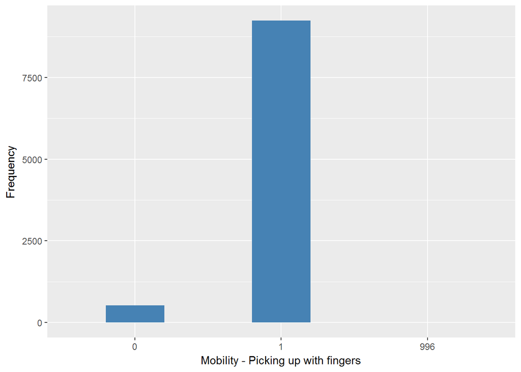

#### 2.1.3.4 Validation

|  | 1->0 | 0->1 | -1->996 |
| --- | --- | --- | --- |
| BeforeH | 528 | 9239 | 4 |
| AfterH | 528 | 9239 | 4 |

### 2.1.4 Wave 4

#### 2.1.4.1 Study-specific variable description

| **Name** | `hemobpi` |
| --- | --- |
| **Label** | `Difficulty picking up 5p coin from table` |
| **Table name** | `wave_4_elsa_data_v3` |
| **Categories** | `0 = No; 1 = Yes` |
| **Missings** | `-9 = Refusal; -8 = Don't Know` |
| **Description** |  |

hemobpi

| Sample size | Missing values |
| --- | --- |
| 11050 | 10 |

Category

|  | 0 | 1 |
| --- | --- | --- |
| Frequency | 10449.00 | 591.00 |
| Percentage | 94.56 | 5.35 |

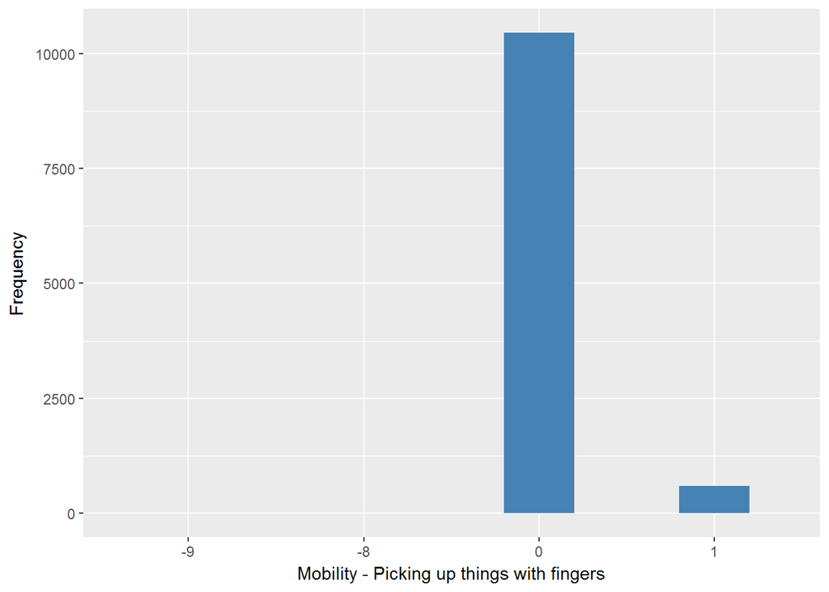

#### 2.1.4.2 Harmonisation algorithm

To compute the harmonize variable from the study-specific variable it has to be recoded as follows:

- `1 into 0`
- `0 into 1`
- `-9 Refusal into 997`
- `-8 Don't know into 998`

**R script:**

```r
ELSA_ds_w4 <- tibble(id = ELSA_w4_mob_coin$id)
ELSA_ds_w4$mob_coin <- car::recode(ELSA_w4_mob_coin$hemobpi, "0 = '1';1 = '0';-9 = '997';-8 = '998' ")
ELSA_ds_w4$mob_coin <- labelled(ELSA_ds_w4$mob_coin, labels = c(Yes = 0, No = 1,
    Missing = 999, Do_not_know = 998, Refuse = 997, Not_applicable = 996, Does_not_answer = 995,
    Not_attempt_not_done = 994, Disable_to_measure = 993, Impute = 992, CAPI_interviewer_error = 991))
```

#### 2.1.4.3 Statistical description of the new harmonised variable

mob_coin

| Sample size | Missing values |
| --- | --- |
| 11050 | 10 |

Category

|  | 0 | 1 |
| --- | --- | --- |
| Frequency | 591.00 | 10449.00 |
| Percentage | 5.35 | 94.56 |

Type of missing

|  | 991 | 992 | 993 | 994 | 995 | 996 | 997 | 998 | 999 | NA |
| --- | --- | --- | --- | --- | --- | --- | --- | --- | --- | --- |
| Frequency | 0 | 0 | 0 | 0 | 0 | 0 | 7.00 | 3.00 | 0 | 0 |
| Percentage | 0 | 0 | 0 | 0 | 0 | 0 | 0.06 | 0.03 | 0 | 0 |

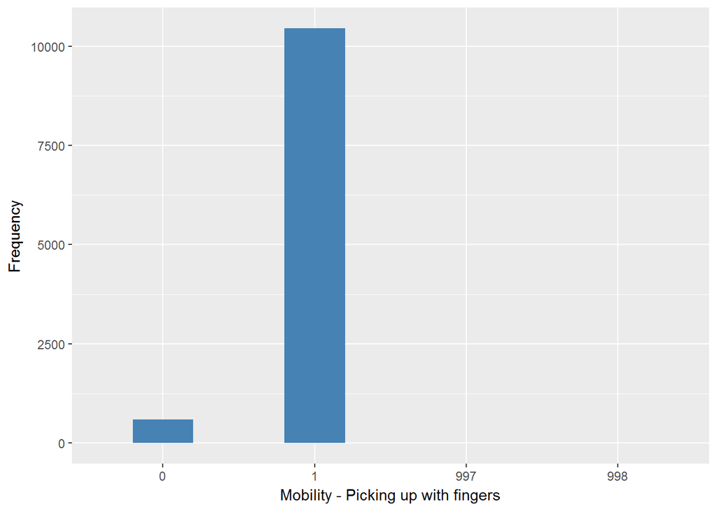

#### 2.1.4.4 Validation

|  | 1->0 | 0->1 | -9->997 | -8->998 |
| --- | --- | --- | --- | --- |
| BeforeH | 591 | 10449 | 7 | 3 |
| AfterH | 591 | 10449 | 7 | 3 |

### 2.1.5 Wave 5

#### 2.1.5.1 Study-specific variable description

| **Name** | `hemobpi` |
| --- | --- |
| **Label** | `Difficulty picking up 5p coin from table` |
| **Table name** | `wave_5_elsa_data_v4` |
| **Categories** | `0 = No; 1 = Yes` |
| **Missings** | `-9 = Refusal; -8 = Don't Know` |
| **Description** |  |

hemobpi

| Sample size | Missing values |
| --- | --- |
| 10274 | 9 |

Category

|  | 0 | 1 |
| --- | --- | --- |
| Frequency | 9647.0 | 618.00 |
| Percentage | 93.9 | 6.02 |

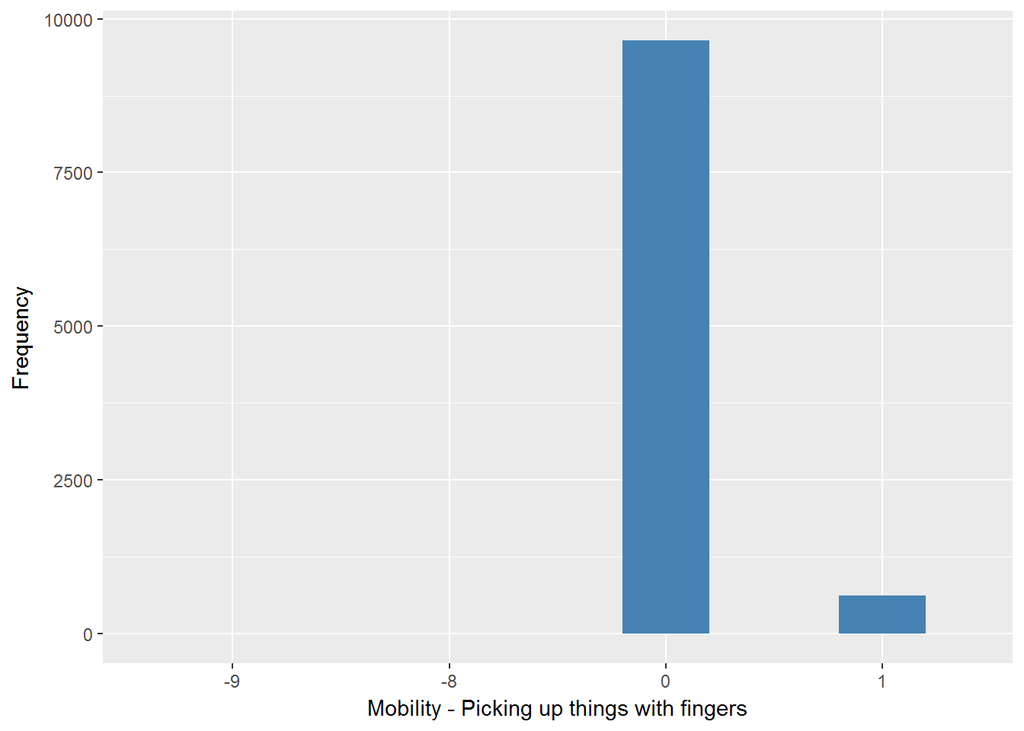

#### 2.1.5.2 Harmonisation algorithm

To compute the harmonize variable from the study-specific variable it has to be recoded as follows:

- `1 into 0`
- `0 into 1`
- `-9 Refusal into 997`
- `-8 Don't know into 998`

**R script:**

```r
ELSA_ds_w5 <- tibble(id = ELSA_w5_mob_coin$id)
ELSA_ds_w5$mob_coin <- car::recode(ELSA_w5_mob_coin$hemobpi, "0 = '1';1 = '0';-9 = '997';-8 = '998'")
ELSA_ds_w5$mob_coin <- labelled(ELSA_ds_w5$mob_coin, labels = c(Yes = 0, No = 1,
    Missing = 999, Do_not_know = 998, Refuse = 997, Not_applicable = 996, Does_not_answer = 995,
    Not_attempt_not_done = 994, Disable_to_measure = 993, Impute = 992, CAPI_interviewer_error = 991))
```

#### 2.1.5.3 Statistical description of the new harmonised variable

mob_coin

| Sample size | Missing values |
| --- | --- |
| 10274 | 9 |

Category

|  | 0 | 1 |
| --- | --- | --- |
| Frequency | 618.00 | 9647.0 |
| Percentage | 6.02 | 93.9 |

Type of missing

|  | 991 | 992 | 993 | 994 | 995 | 996 | 997 | 998 | 999 | NA |
| --- | --- | --- | --- | --- | --- | --- | --- | --- | --- | --- |
| Frequency | 0 | 0 | 0 | 0 | 0 | 0 | 6.00 | 3.00 | 0 | 0 |
| Percentage | 0 | 0 | 0 | 0 | 0 | 0 | 0.06 | 0.03 | 0 | 0 |

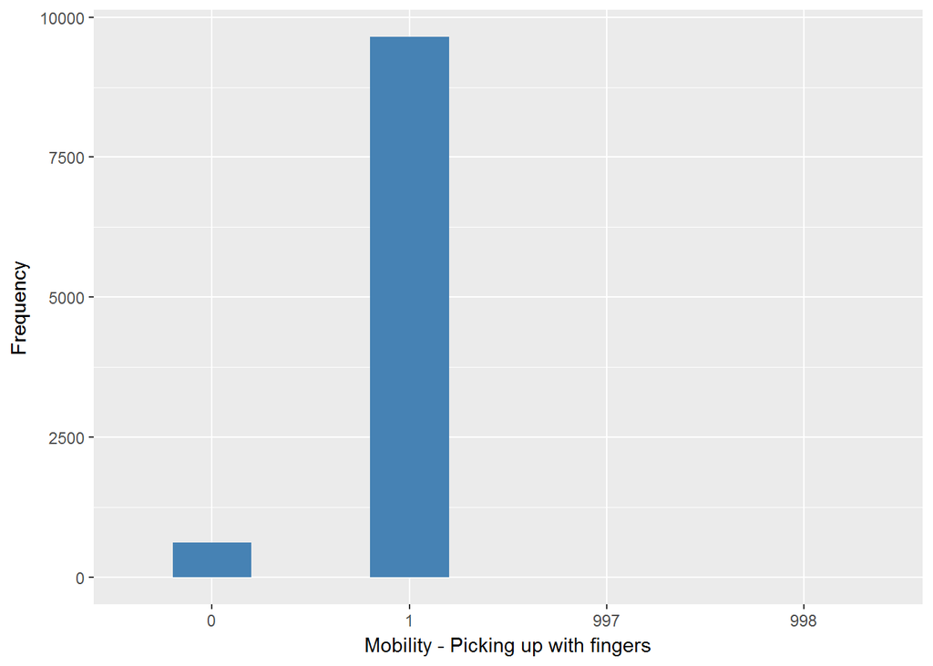

#### 2.1.5.4 Validation

|  | 1->0 | 0->1 | -9->997 | -8->998 |
| --- | --- | --- | --- | --- |
| BeforeH | 618 | 9647 | 6 | 3 |
| AfterH | 618 | 9647 | 6 | 3 |

### 2.1.6 Wave 6

#### 2.1.6.1 Study-specific variable description

| **Name** | `hemobpi` |
| --- | --- |
| **Label** | `Difficulty picking up 5p coin from table` |
| **Table name** | `wave_6_elsa_data_v2` |
| **Categories** | `0 = No; 1 = Yes` |
| **Missings** | `-9 = Refusal; -8 = Don't Know` |
| **Description** |  |

hemobpi

| Sample size | Missing values |
| --- | --- |
| 10601 | 5 |

Category

|  | 0 | 1 |
| --- | --- | --- |
| Frequency | 9983.00 | 613.00 |
| Percentage | 94.17 | 5.78 |

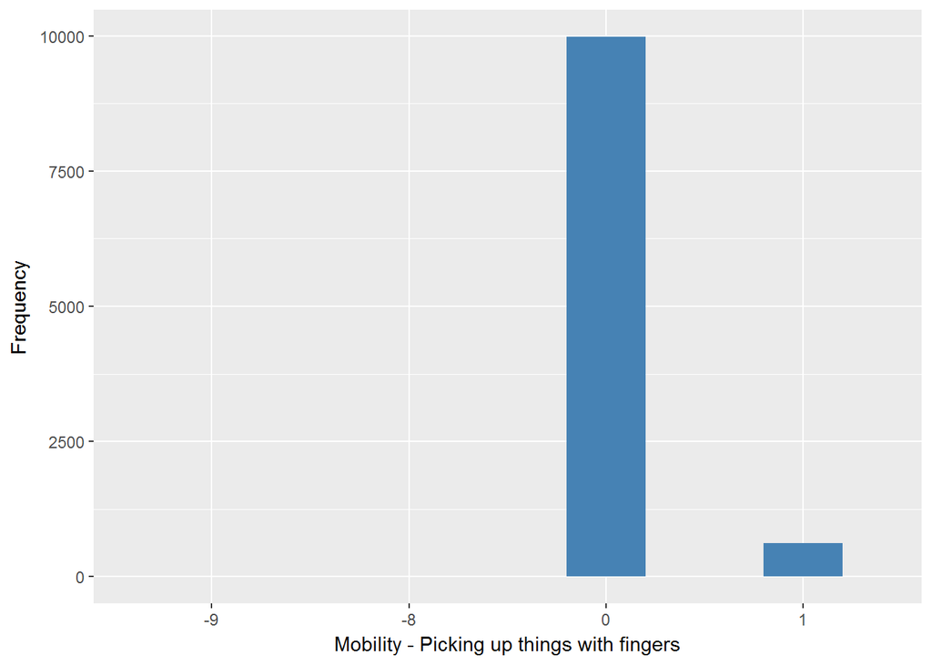

#### 2.1.6.2 Harmonisation algorithm

To compute the harmonize variable from the study-specific variable it has to be recoded as follows:

- `1 into 0`
- `0 into 1`
- `-9 Refusal into 997`
- `-8 Don't know into 998`

**R script:**

```r
ELSA_ds_w6 <- tibble(id = ELSA_w6_mob_coin$id)
ELSA_ds_w6$mob_coin <- car::recode(ELSA_w6_mob_coin$hemobpi, "0 = '1';1 = '0';-9 = '997';-8 = '998' ")
ELSA_ds_w6$mob_coin <- labelled(ELSA_ds_w6$mob_coin, labels = c(Yes = 0, No = 1,
    Missing = 999, Do_not_know = 998, Refuse = 997, Not_applicable = 996, Does_not_answer = 995,
    Not_attempt_not_done = 994, Disable_to_measure = 993, Impute = 992, CAPI_interviewer_error = 991))
```

#### 2.1.6.3 Statistical description of the new harmonised variable

mob_coin

| Sample size | Missing values |
| --- | --- |
| 10601 | 5 |

Category

|  | 0 | 1 |
| --- | --- | --- |
| Frequency | 613.00 | 9983.00 |
| Percentage | 5.78 | 94.17 |

Type of missing

|  | 991 | 992 | 993 | 994 | 995 | 996 | 997 | 998 | 999 | NA |
| --- | --- | --- | --- | --- | --- | --- | --- | --- | --- | --- |
| Frequency | 0 | 0 | 0 | 0 | 0 | 0 | 3.00 | 2.00 | 0 | 0 |
| Percentage | 0 | 0 | 0 | 0 | 0 | 0 | 0.03 | 0.02 | 0 | 0 |

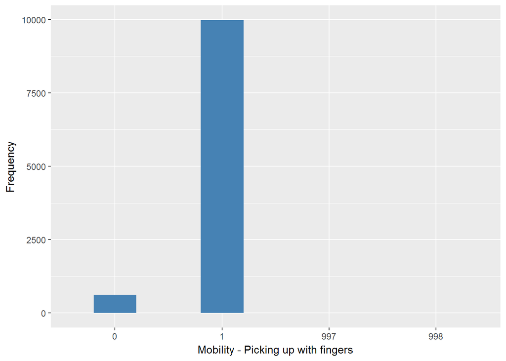

#### 2.1.6.4 Validation

|  | 1->0 | 0->1 | -9->997 | -8->998 |
| --- | --- | --- | --- | --- |
| BeforeH | 613 | 9983 | 3 | 2 |
| AfterH | 613 | 9983 | 3 | 2 |

### 2.1.7 Wave 7

#### 2.1.7.1 Study-specific variable description

| **Name** | `hemobpi` |
| --- | --- |
| **Label** | `Difficulty picking up 5p coin from table` |
| **Table name** | `wave_7_elsa_data` |
| **Categories** | `0 = No; 1 = Yes` |
| **Missings** | `-8 = Don't Know` |
| **Description** |  |

hemobpi

| Sample size | Missing values |
| --- | --- |
| 9666 | 2 |

Category

|  | 0 | 1 |
| --- | --- | --- |
| Frequency | 9078.00 | 586.00 |
| Percentage | 93.92 | 6.06 |

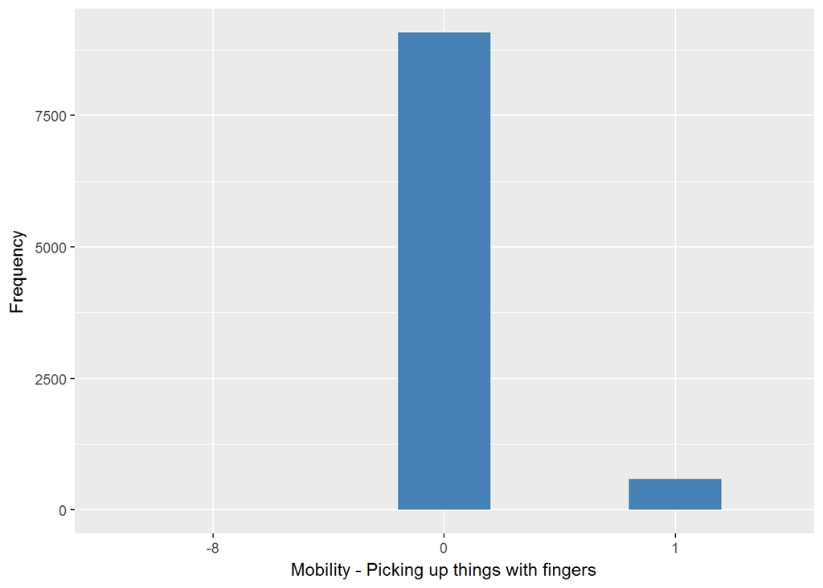

#### 2.1.7.2 Harmonisation algorithm

To compute the harmonize variable from the study-specific variable it has to be recoded as follows:

- `1 into 0`
- `0 into 1`
- `-8 Don't know into 998`

**R script:**

```r
ELSA_ds_w7 <- tibble(id = ELSA_w7_mob_coin$id)
ELSA_ds_w7$mob_coin <- car::recode(ELSA_w7_mob_coin$hemobpi, "0 = '1';1 = '0';-8 = '998' ")
ELSA_ds_w7$mob_coin <- labelled(ELSA_ds_w7$mob_coin, labels = c(Yes = 0, No = 1,
    Missing = 999, Do_not_know = 998, Refuse = 997, Not_applicable = 996, Does_not_answer = 995,
    Not_attempt_not_done = 994, Disable_to_measure = 993, Impute = 992, CAPI_interviewer_error = 991))
```

#### 2.1.7.3 Statistical description of the new harmonised variable

mob_coin

| Sample size | Missing values |
| --- | --- |
| 9666 | 2 |

Category

|  | 0 | 1 |
| --- | --- | --- |
| Frequency | 586.00 | 9078.00 |
| Percentage | 6.06 | 93.92 |

Type of missing

|  | 991 | 992 | 993 | 994 | 995 | 996 | 997 | 998 | 999 | NA |
| --- | --- | --- | --- | --- | --- | --- | --- | --- | --- | --- |
| Frequency | 0 | 0 | 0 | 0 | 0 | 0 | 0 | 2.00 | 0 | 0 |
| Percentage | 0 | 0 | 0 | 0 | 0 | 0 | 0 | 0.02 | 0 | 0 |

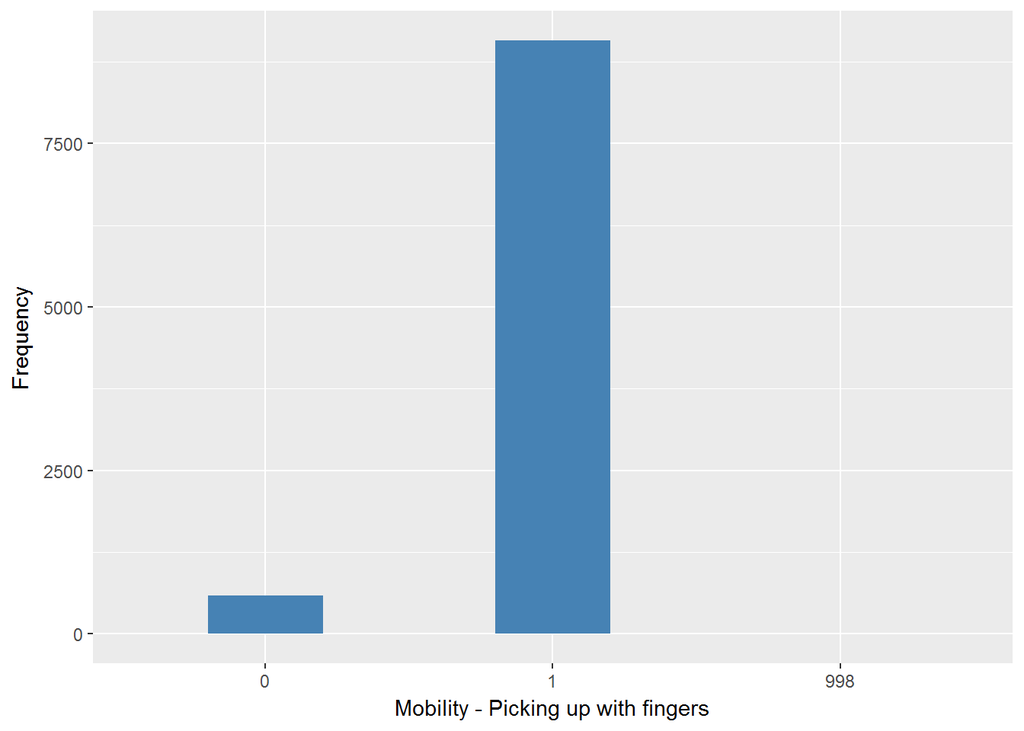

#### 2.1.7.4 Validation

|  | 1->0 | 0->1 | -8->998 |
| --- | --- | --- | --- |
| BeforeH | 586 | 9078 | 2 |
| AfterH | 586 | 9078 | 2 |

## 2.2 Summary of descriptive statistics of the harmonised variable accross populations and waves

Two tables are generated:

1. Percentages of categories in each harmonised variable.
2. Frequencies and percentages of individuals with different trajectories. To avoid too large table, Only trajectories with percentages larger than 0.3 are shown.

**R script:**

```r
ELSA_ds_w1$mob_coin <- labelled(ELSA_ds_w1$mob_coin, labels = c(Presence = 0,
    Absence = 1, Missing = 999, Do_not_know = 998, Refuse = 997, Not_applicable = 996,
    Does_not_answer = 995, Not_attempt_not_done = 994, Disable_to_measure = 993,
    Impute = 992, CAPI_interviewer_error = 991))
ELSA_ds_w2$mob_coin <- labelled(ELSA_ds_w2$mob_coin, labels = c(Presence = 0,
    Absence = 1, Missing = 999, Do_not_know = 998, Refuse = 997, Not_applicable = 996,
    Does_not_answer = 995, Not_attempt_not_done = 994, Disable_to_measure = 993,
    Impute = 992, CAPI_interviewer_error = 991))
ELSA_ds_w3$mob_coin <- labelled(ELSA_ds_w3$mob_coin, labels = c(Presence = 0,
    Absence = 1, Missing = 999, Do_not_know = 998, Refuse = 997, Not_applicable = 996,
    Does_not_answer = 995, Not_attempt_not_done = 994, Disable_to_measure = 993,
    Impute = 992, CAPI_interviewer_error = 991))
ELSA_ds_w4$mob_coin <- labelled(ELSA_ds_w4$mob_coin, labels = c(Presence = 0,
    Absence = 1, Missing = 999, Do_not_know = 998, Refuse = 997, Not_applicable = 996,
    Does_not_answer = 995, Not_attempt_not_done = 994, Disable_to_measure = 993,
    Impute = 992, CAPI_interviewer_error = 991))
ELSA_ds_w5$mob_coin <- labelled(ELSA_ds_w5$mob_coin, labels = c(Presence = 0,
    Absence = 1, Missing = 999, Do_not_know = 998, Refuse = 997, Not_applicable = 996,
    Does_not_answer = 995, Not_attempt_not_done = 994, Disable_to_measure = 993,
    Impute = 992, CAPI_interviewer_error = 991))
ELSA_ds_w6$mob_coin <- labelled(ELSA_ds_w6$mob_coin, labels = c(Presence = 0,
    Absence = 1, Missing = 999, Do_not_know = 998, Refuse = 997, Not_applicable = 996,
    Does_not_answer = 995, Not_attempt_not_done = 994, Disable_to_measure = 993,
    Impute = 992, CAPI_interviewer_error = 991))
ELSA_ds_w7$mob_coin <- labelled(ELSA_ds_w7$mob_coin, labels = c(Presence = 0,
    Absence = 1, Missing = 999, Do_not_know = 998, Refuse = 997, Not_applicable = 996,
    Does_not_answer = 995, Not_attempt_not_done = 994, Disable_to_measure = 993,
    Impute = 992, CAPI_interviewer_error = 991))

tt <- frq(ELSA_ds_w1$mob_coin)[[1]][, c(1:2, 4)]
tt[4] <- frq(ELSA_ds_w2$mob_coin)[[1]][, c(4)]
tt[5] <- frq(ELSA_ds_w3$mob_coin)[[1]][, c(4)]
tt[6] <- frq(ELSA_ds_w4$mob_coin)[[1]][, c(4)]
tt[7] <- frq(ELSA_ds_w5$mob_coin)[[1]][, c(4)]
tt[8] <- frq(ELSA_ds_w6$mob_coin)[[1]][, c(4)]
tt[9] <- frq(ELSA_ds_w7$mob_coin)[[1]][, c(4)]
tt[13, ] <- c("n", "sample size", length(ELSA_ds_w1$mob_coin), length(ELSA_ds_w2$mob_coin),
    length(ELSA_ds_w3$mob_coin), length(ELSA_ds_w4$mob_coin), length(ELSA_ds_w5$mob_coin),
    length(ELSA_ds_w6$mob_coin), length(ELSA_ds_w7$mob_coin))
names(tt) <- c("val", "label", "w1", "w2", "w3", "w4", "w5", "w6", "w7")
kable(tt)
```

| val | label | w1 | w2 | w3 | w4 | w5 | w6 | w7 |
| --- | --- | --- | --- | --- | --- | --- | --- | --- |
| 0 | Presence | 4.97 | 5.41 | 5.4 | 5.35 | 6.02 | 5.78 | 6.06 |
| 1 | Absence | 93.45 | 94.56 | 94.56 | 94.56 | 93.9 | 94.17 | 93.92 |
| 991 | CAPI_interviewer_error | 0 | 0 | 0 | 0 | 0 | 0 | 0 |
| 992 | Impute | 0 | 0 | 0 | 0 | 0 | 0 | 0 |
| 993 | Disable_to_measure | 0 | 0 | 0 | 0 | 0 | 0 | 0 |
| 994 | Not_attempt_not_done | 0 | 0 | 0 | 0 | 0 | 0 | 0 |
| 995 | Does_not_answer | 0 | 0 | 0 | 0 | 0 | 0 | 0 |
| 996 | Not_applicable | 1.45 | 0 | 0.04 | 0 | 0 | 0 | 0 |
| 997 | Refuse | 0.03 | 0.01 | 0 | 0.06 | 0.06 | 0.03 | 0 |
| 998 | Do_not_know | 0.1 | 0.02 | 0 | 0.03 | 0.03 | 0.02 | 0.02 |
| 999 | Missing | 0 | 0 | 0 | 0 | 0 | 0 | 0 |
| NA | NA | 0 | 0 | 0 | 0 | 0 | 0 | 0 |
| n | sample size | 12099 | 9432 | 9771 | 11050 | 10274 | 10601 | 9666 |

```r
dbb <- merge(ELSA_m_ds_w1, ELSA_m_ds_w2, by = "id", suffixes = c(".w1", ".w2"),
    all = T)
dbb <- merge(dbb, ELSA_m_ds_w3, by = "id", all = T)
dbb <- merge(dbb, ELSA_m_ds_w4, by = "id", suffixes = c(".w3", ".w4"), all = T)
dbb <- merge(dbb, ELSA_m_ds_w5, by = "id", all = T)
dbb <- merge(dbb, ELSA_m_ds_w6, by = "id", suffixes = c(".w5", ".w6"), all = T)
dbb <- merge(dbb, ELSA_m_ds_w7, by = "id", all = T)
names(dbb) <- c("id", "w1", "w2", "w3", "w4", "w5", "w6", "w7")
v.dbb <- paste(dbb[, 2], dbb[, 3], dbb[, 4], dbb[, 5], dbb[, 6], dbb[, 7], dbb[,
    8], sep = "")
f.dbb <- frq(v.dbb)[[1]][, c(1, 2, 4)]
kable(f.dbb[f.dbb[, 3] >= 0.3, ])
```

|  | val | frq | raw.prc |
| --- | --- | --- | --- |
| 136 | 0NANANANANANA | 131 | 0.71 |
| 277 | 1111110 | 87 | 0.47 |
| 278 | 1111111 | 3690 | 19.96 |
| 279 | 111111NA | 513 | 2.77 |
| 281 | 11111NA1 | 59 | 0.32 |
| 282 | 11111NANA | 366 | 1.98 |
| 290 | 1111NANANA | 499 | 2.70 |
| 298 | 111NA111 | 100 | 0.54 |
| 309 | 111NANANANA | 777 | 4.20 |
| 320 | 11NA1111 | 101 | 0.55 |
| 343 | 11NANANANANA | 1132 | 6.12 |
| 368 | 1NA11111 | 75 | 0.41 |
| 384 | 1NA1NANANANA | 91 | 0.49 |
| 393 | 1NANA1111 | 58 | 0.31 |
| 421 | 1NANANANANANA | 1869 | 10.11 |
| 504 | NANA11111 | 800 | 4.33 |
| 505 | NANA1111NA | 113 | 0.61 |
| 507 | NANA111NANA | 82 | 0.44 |
| 511 | NANA11NANANA | 118 | 0.64 |
| 516 | NANA1NA111 | 55 | 0.30 |
| 524 | NANA1NANANANA | 298 | 1.61 |
| 558 | NANANA1111 | 1530 | 8.28 |
| 559 | NANANA111NA | 244 | 1.32 |
| 562 | NANANA11NANA | 168 | 0.91 |
| 568 | NANANA1NANANA | 344 | 1.86 |
| 574 | NANANANA111 | 77 | 0.42 |
| 583 | NANANANANA11 | 907 | 4.91 |
| 584 | NANANANANA1NA | 263 | 1.42 |
| 586 | NANANANANANA1 | 501 | 2.71 |
| 587 | NANANANANANANA | 92 | 0.50 |

# 3 Quality estimation

No comments.